# 第13講 時系列解析

#### AirPassengersデータの分析

データの時間に関する情報(月ごとのデータ)を表示する．

```r
AirPassengers |> tsp()
```

```
[1] 1949.000 1960.917   12.000
```

データを表示する．

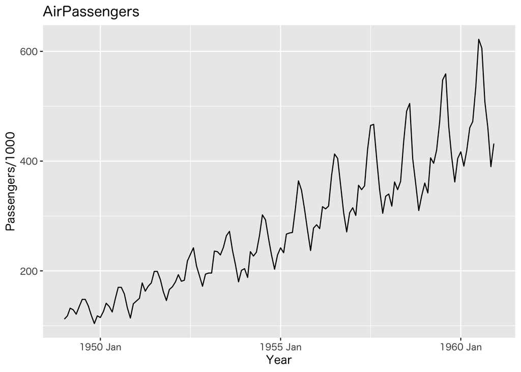

```r
AirPassengers |> as_tsibble() |>
    autoplot(value) +
    labs(title = "AirPassengers",
         x = "Year", y = "Passengers/1000")
```

ほぼ線形のトレンドと増大する分散変動があることがわかる．

対数変換したデータを表示する．

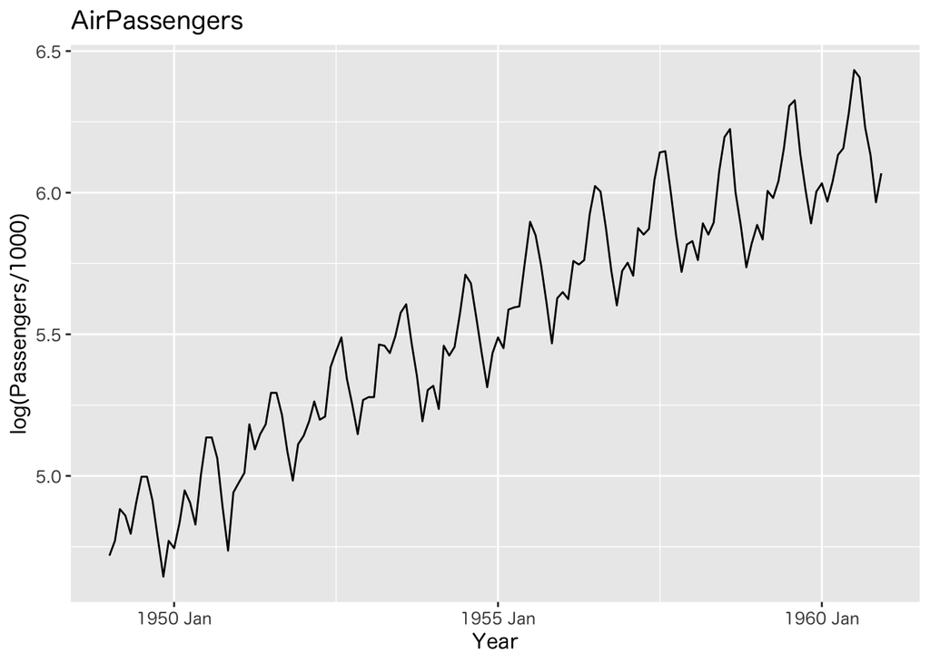

```r
AirPassengers |> log() |> as_tsibble() |>
    autoplot(value) +
    labs(title = "AirPassengers",
         x = "Year", y = "log(Passengers/1000)")
```

対数変換により分散変動が安定化していることがわかる． 以下では対数変換したデータを扱う．

```r
ap_tsbl <- AirPassengers |> as_tsibble()
ap_train <- ap_tsbl |> filter_index(~ "1958-12")   # 訓練データ
ap_test  <- ap_tsbl |> filter_index("1959-01" ~ .) # 試験データ(2年分)
```

まずトレンド(明らかな上昇傾向)について考察する． 階差を取ることにより定常化できるか検討する．

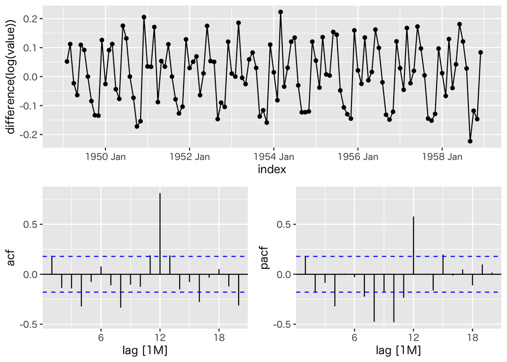

```r
ap_train |>
    gg_tsdisplay(difference(log(value)),
                 plot_type = "partial")
```

季節成分について考察するために， 12ヶ月で階差を取って同様に検討する．

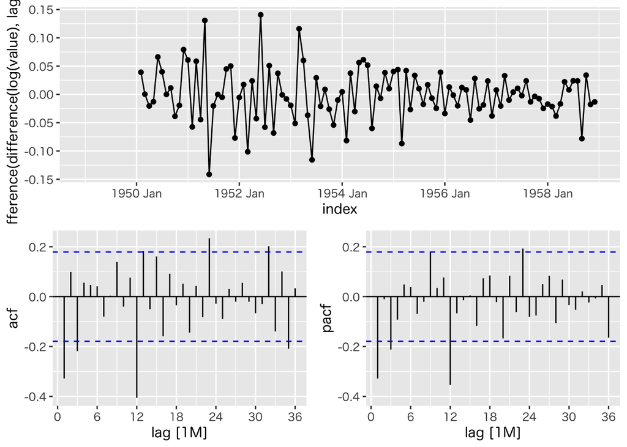

```r
ap_train |>
    gg_tsdisplay(difference(difference(log(value), lag = 12)),
                 lag_max = 36,
                 plot_type = "partial")
```

lag=1,3,12(1年) に若干偏自己相関が残っている． また lag=36(3年) まで見ると上記以外の偏自己相関は誤差内といえる．

SARIMAモデルを作成する．

階差および季節成分の自己相関・偏自己相関から， 階差系列については ARMA(pまたはq=1-3)， 季節成分 については ARMA(pまたはq=1-2) あたりを考える必要がありそう． いくつかのARIMAモデルの推定を行う．

```r
ap_fit <-
    ap_train |>
    model( # 名前に特殊な文字を含む場合は``で括る
        `arima(0,1,2)(0,1,1)` = ARIMA(log(value) ~ pdq(0,1,2) + PDQ(0,1,1)),
        `arima d=1 D=1` = ARIMA(log(value) ~ pdq(d = 1) + PDQ(D = 1)),
        `arima auto` = ARIMA(log(value)),
        `ets` = ETS(log(value)),
        )
```

次数を指定したモデル order=pdq(0,1,2), seasonal=PDQ(0,1,1) を検討する．

```r
ap_fit |> select(`arima(0,1,2)(0,1,1)`) |> report() # 推定されたモデルの概要
```

```
Series: value
Model: ARIMA(0,1,2)(0,1,1)[12]
Transformation: log(value)

Coefficients:
          ma1      ma2     sma1
      -0.3425  -0.0224  -0.5406
s.e.   0.0978   0.0947   0.0877

sigma^2 estimated as 0.001445:  log likelihood=197.54
AIC=-387.07   AICc=-386.68   BIC=-376.38
```

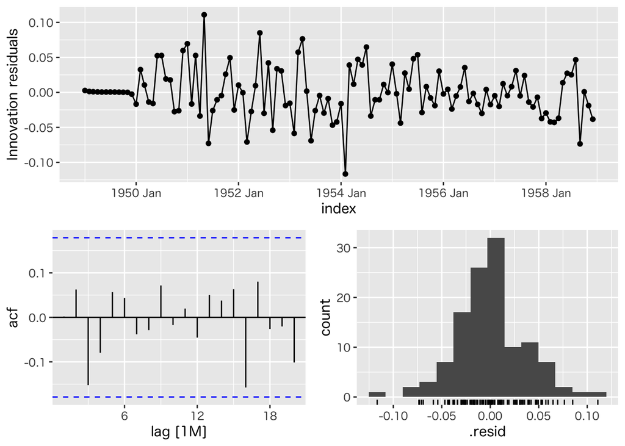

```r
ap_fit |> select(`arima(0,1,2)(0,1,1)`) |>
    gg_tsresiduals() # 残差の診断(モデルの診断)
```

```r
ap_fit |> select(`arima(0,1,2)(0,1,1)`) |>
    augment() |> features(.innov, ljung_box, lag = 12) # Ljung-Box検定
```

```
# A tibble: 1 × 3
  .model              lb_stat lb_pvalue
  <chr>                 <dbl>     <dbl>
1 arima(0,1,2)(0,1,1)    6.19     0.906
```

残差の自己相関は小さいが残差の正規性は低い． 残差に関する Ljung-Box 検定は

- 帰無仮説 : 残差は無作為
- 対立仮説 : 残差は無作為でない

であるので，p値が高い方が良い．

階差・季節成分の階差のみを指定したモデルを確認する．

```r
ap_fit |> select(`arima d=1 D=1`) |> report()
```

```
Series: value
Model: ARIMA(0,1,1)(0,1,1)[12]
Transformation: log(value)

Coefficients:
          ma1     sma1
      -0.3424  -0.5405
s.e.   0.1009   0.0877

sigma^2 estimated as 0.001432:  log likelihood=197.51
AIC=-389.02   AICc=-388.78   BIC=-381
```

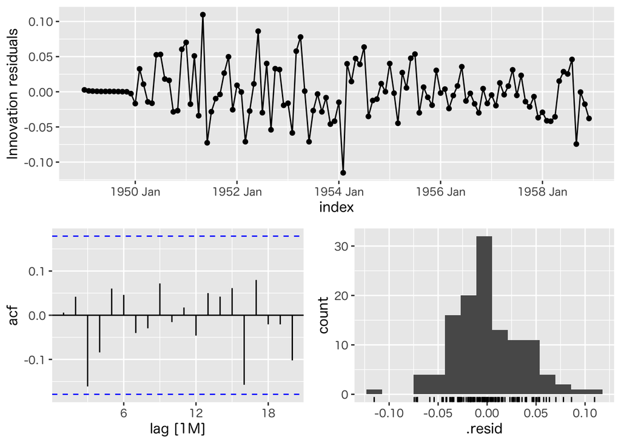

```r
ap_fit |> select(`arima d=1 D=1`) |>
    gg_tsresiduals()
```

```r
ap_fit |> select(`arima d=1 D=1`) |>
    augment() |> features(.innov, ljung_box, lag = 12)
```

```
# A tibble: 1 × 3
  .model        lb_stat lb_pvalue
  <chr>           <dbl>     <dbl>
1 arima d=1 D=1    6.47     0.891
```

自動的に次数の選択を行ったモデルを確認する．

```r
ap_fit |> select(`arima auto`) |> report()
```

```
Series: value
Model: ARIMA(2,0,0)(0,1,1)[12] w/ drift
Transformation: log(value)

Coefficients:
         ar1     ar2     sma1  constant
      0.6159  0.2356  -0.5562    0.0179
s.e.  0.0944  0.0965   0.0898    0.0017

sigma^2 estimated as 0.001382:  log likelihood=201.77
AIC=-393.53   AICc=-392.95   BIC=-380.12
```

予測値と信頼区間を描画する．

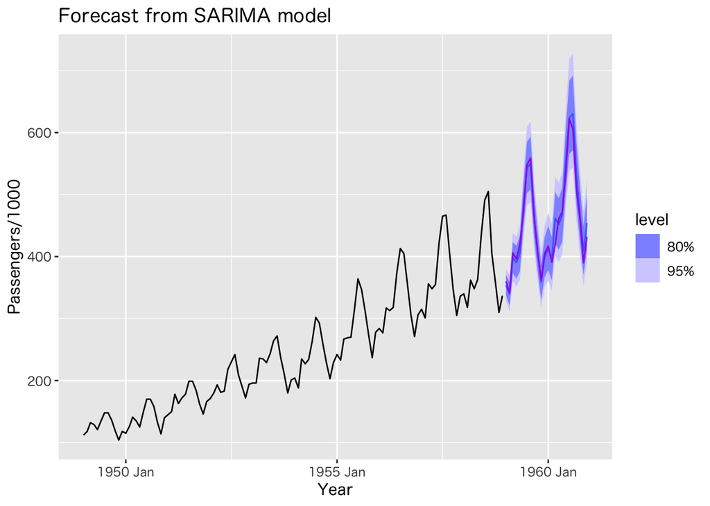

```r
ap_fit |> select(`arima auto`) |>
    forecast(h = nrow(ap_test)) |>
    autoplot(ap_train) +
    autolayer(ap_test, value, colour = "purple") +
    labs(title = "Forecast from SARIMA model",
         x = "Year", y = "Passengers/1000")
```

時系列の分解(トレンド(level+slope) + 季節(12ヶ月周期) + ランダム)を行う ETS (exponential smoothing) モデルを確認する．

```r
ap_fit |> select(`ets`) |> report()
```

```
Series: value
Model: ETS(M,A,M)
Transformation: log(value)
  Smoothing parameters:
    alpha = 0.5480859
    beta  = 0.0001017353
    gamma = 0.0001002554

  Initial states:
     l[0]       b[0]      s[0]     s[-1]     s[-2]    s[-3]   s[-4]    s[-5]
 4.798138 0.01002451 0.9812161 0.9595451 0.9858188 1.012039 1.03667 1.037824
    s[-6]     s[-7]     s[-8]   s[-9]    s[-10]    s[-11]
 1.020521 0.9969978 0.9984623 1.00612 0.9815133 0.9832722

  sigma^2:  0

      AIC      AICc       BIC
-196.6814 -190.6814 -149.2941
```

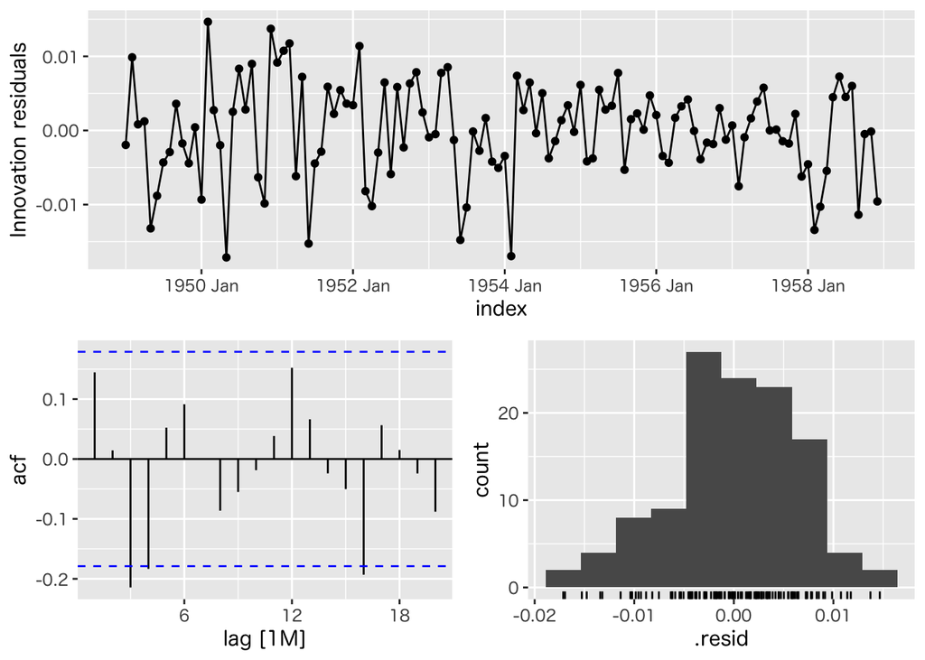

```r
ap_fit |> select(`ets`) |> gg_tsresiduals()
```

```r
ap_fit |> select(`ets`) |> augment() |> features(.innov, ljung_box, lag = 12)
```

```
# A tibble: 1 × 3
  .model lb_stat lb_pvalue
  <chr>    <dbl>     <dbl>
1 ets       18.8    0.0941
```

予測値と信頼区間を描画する．

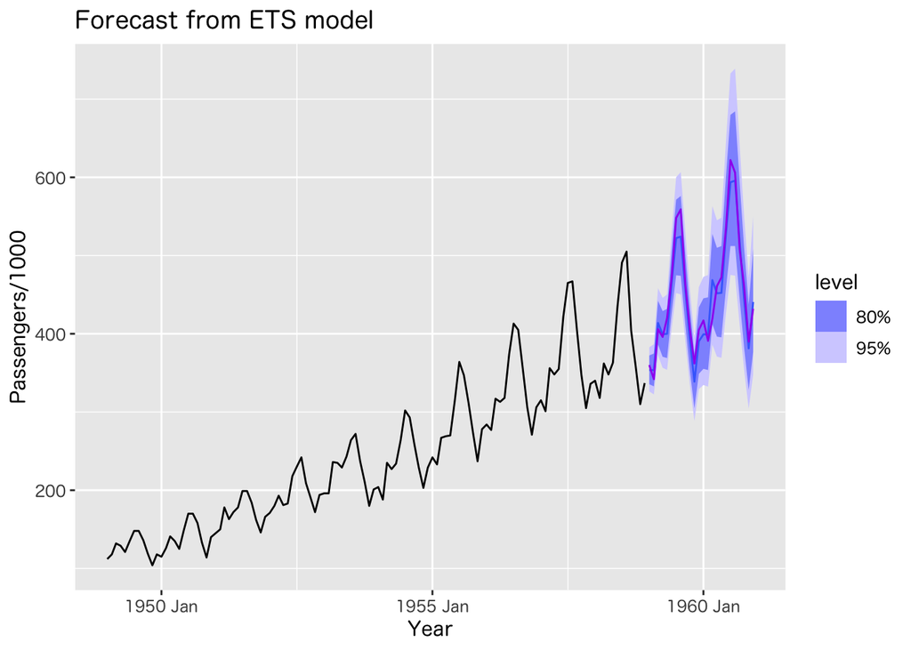

```r
ap_fit |> select(`ets`) |>
    forecast(h = nrow(ap_test)) |>
    autoplot(ap_train) +
    autolayer(ap_test, value, colour = "purple") +
    labs(title = "Forecast from ETS model",
         x = "Year", y = "Passengers/1000")
```

ARIMAとETSを比較する．

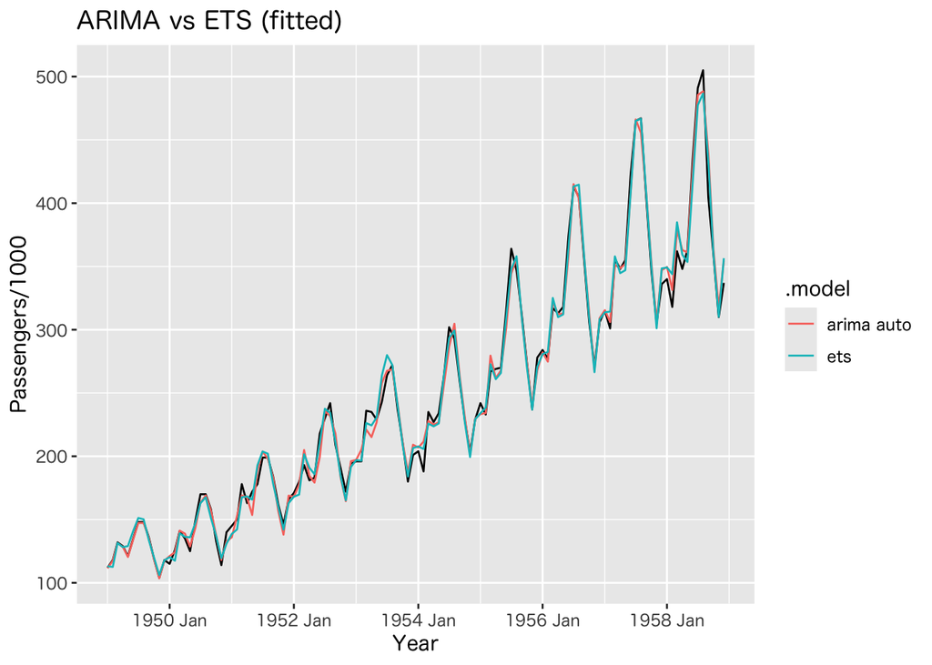

```r
ap_train |>
    autoplot(value) +
    geom_line(aes(y = .fitted, colour = .model),
              data = ap_fit |> select(`arima auto`,`ets`) |> augment()) +
    labs(title = "ARIMA vs ETS (fitted)",
         x = "Year", y = "Passengers/1000")
```

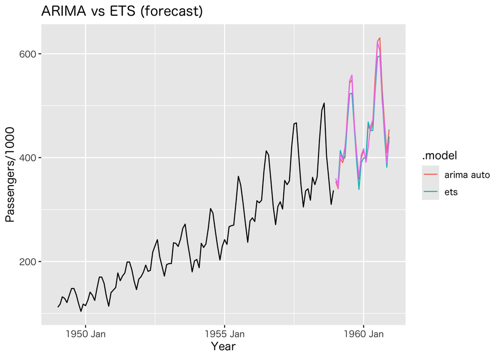

```r
ap_fit |> select(`arima auto`,`ets`) |>
    forecast(h = nrow(ap_test)) |>
    autoplot(ap_train, level = NULL) +
    autolayer(ap_test, value, colour = "violet") +
    labs(title = "ARIMA vs ETS (forecast)",
         x = "Year", y = "Passengers/1000")
```